# Immunofluorescence

### Data loading

```r
suppressPackageStartupMessages({
  library(SummarizedExperiment)
  library(SEtools)
  library(edgeR)
  library(DT)
  library(pheatmap)
  library(plotly)
  library(dplyr)
  library(sva)
  library(lme4)
  library(lmerTest)
})
source("Functions/EDC_Functions.R")
source("Functions/CriFormatted.R")
```

### import data KI67

```r
KI <- read.table("Data/Stainings/KI67/CNT.txt",header = F, sep="\t")
KI <- as.data.frame(strsplit(as.character(KI$V1),":"))
a <-  as.data.frame(KI[2,c(2:5)], row.names = as.character(KI[1,1]))
colnames(a)=c("DAPI low thresh", "KI67 low thresh","Area KI67","Area DAPI")
for (i in 2:(length(colnames(KI))/6))
  {
     b <- as.data.frame(KI[2,c(2:5)+ 6*i -6], row.names = as.character(KI[1,i*6 -5]))
     colnames(b) <- colnames(a)
     a <- rbind(a,  b)
  }
CNT <- a
CNT$Expo <- "CNT"

KI <- read.table("Data/Stainings/KI67/DMSO.txt",header = F, sep="\t")
KI <- as.data.frame(strsplit(as.character(KI$V1),":"))
a <-  as.data.frame(KI[2,c(2:5)], row.names = as.character(KI[1,1]))
colnames(a)=c("DAPI low thresh", "KI67 low thresh","Area KI67","Area DAPI")
for (i in 2:(length(colnames(KI))/6))
  {
     b <- as.data.frame(KI[2,c(2:5)+ 6*i -6], row.names = as.character(KI[1,i*6 -5]))
     colnames(b) <- colnames(a)
     a <- rbind(a,  b)
  }
DMSO <- a
DMSO$Expo <- "DMSO"


KI <- read.table("Data/Stainings/KI67/T3.txt",header = F, sep="\t")
KI <- as.data.frame(strsplit(as.character(KI$V1),":"))
a <-  as.data.frame(KI[2,c(2:5)], row.names = as.character(KI[1,1]))
colnames(a)=c("DAPI low thresh", "KI67 low thresh","Area KI67","Area DAPI")
for (i in 2:(length(colnames(KI))/6))
  {
     b <- as.data.frame(KI[2,c(2:5)+ 6*i -6], row.names = as.character(KI[1,i*6 -5]))
     colnames(b) <- colnames(a)
     a <- rbind(a,  b)
  }
T3 <- a
T3$Expo <- "T3"

KI <- read.table("Data/Stainings/KI67/BPA.txt",header = F, sep="\t")
KI <- as.data.frame(strsplit(as.character(KI$V1),":"))
a <-  as.data.frame(KI[2,c(2:5)], row.names = as.character(KI[1,1]))
colnames(a)=c("DAPI low thresh", "KI67 low thresh","Area KI67","Area DAPI")
for (i in 2:(length(colnames(KI))/6))
  {
     b <- as.data.frame(KI[2,c(2:5)+ 6*i -6], row.names = as.character(KI[1,i*6 -5]))
     colnames(b) <- colnames(a)
     a <- rbind(a,  b)
  }
BPA <- a
BPA$Expo <- "BPA"

KI <- read.table("Data/Stainings/KI67/MixN1X.txt",header = F, sep="\t")
KI <- as.data.frame(strsplit(as.character(KI$V1),":"))
a <-  as.data.frame(KI[2,c(2:5)], row.names = as.character(KI[1,1]))
colnames(a)=c("DAPI low thresh", "KI67 low thresh","Area KI67","Area DAPI")
for (i in 2:(length(colnames(KI))/6))
  {
     b <- as.data.frame(KI[2,c(2:5)+ 6*i -6], row.names = as.character(KI[1,i*6 -5]))
     colnames(b) <- colnames(a)
     a <- rbind(a,  b)
  }
MixN1X <- a
MixN1X$Expo <- "MixN1X"

KI <- read.table("Data/Stainings/KI67/MixN1000X.txt",header = F, sep="\t")
KI <- as.data.frame(strsplit(as.character(KI$V1),":"))
a <-  as.data.frame(KI[2,c(2:5)], row.names = as.character(KI[1,1]))
colnames(a)=c("DAPI low thresh", "KI67 low thresh","Area KI67","Area DAPI")
for (i in 2:(length(colnames(KI))/6))
  {
     b <- as.data.frame(KI[2,c(2:5)+ 6*i -6], row.names = as.character(KI[1,i*6 -5]))
     colnames(b) <- colnames(a)
     a <- rbind(a,  b)
  }
MixN1000X <- a
MixN1000X$Expo <- "MixN1000X"

KI <- rbind(CNT,DMSO,T3,BPA,MixN1X,MixN1000X)
KI$`DAPI low thresh`<- as.numeric(as.character(KI$`DAPI low thresh`))
KI$`KI67 low thresh`<- as.numeric(as.character(KI$`KI67 low thresh`))
KI$`Area KI67`<- as.numeric(as.character(KI$`Area KI67`))
KI$`Area DAPI`<- as.numeric(as.character(KI$`Area DAPI`))
KI$ratio <- KI$`Area KI67`/KI$`Area DAPI`
```

### Violin plot the ratio between KI67area and DAPIarea

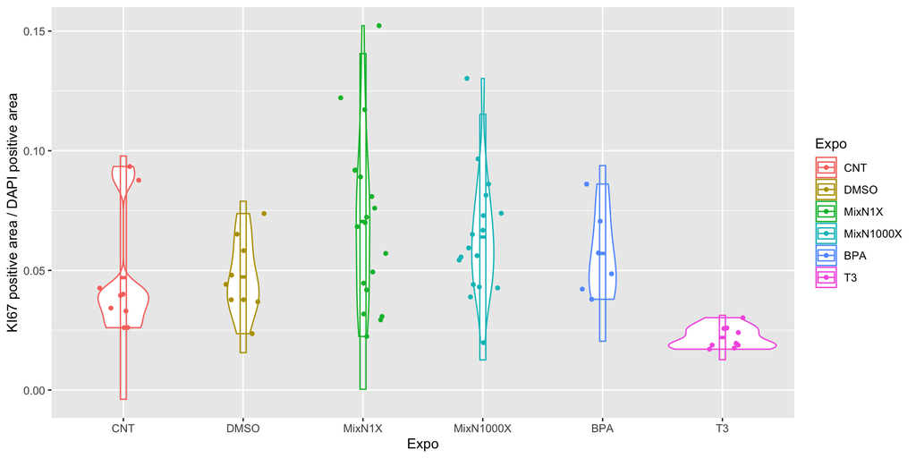

```r
#boxplot(KI67$ratio~KI67$Expo)
#KI$Expo <- factor(KI$Expo, levels=unique(KI$Expo))
KI$Expo <- factor(KI$Expo, levels=c("CNT","DMSO","MixN1X","MixN1000X","BPA","T3" ))
#KI$Expo <- factor(KI$Expo, levels=c("Y", "X", "Z"))
ggplot(KI, aes(x=Expo, y=ratio, color=Expo)) +
geom_violin() +
stat_summary(fun.data="mean_sdl", geom="crossbar", width=0.05) +
geom_jitter(shape=16, position=position_jitter(0.2)) +
ylab("KI67 positive area / DAPI positive area")
```

### Statistical tests

```r
KI$organoid <- gsub("_[0-9]$","",row.names(KI))
mod <- lmer(log(`Area KI67`)~offset(log(`Area DAPI`))+(1|organoid)+Expo, data=KI)
coefficients(summary(mod))[-1,]
```

```
##                  Estimate Std. Error       df    t value   Pr(>|t|)
## ExpoDMSO       0.06084015  0.2824066 18.84486  0.2154346 0.83174297
## ExpoMixN1X     0.41433678  0.2384650 19.89371  1.7375161 0.09775401
## ExpoMixN1000X  0.39949701  0.2402402 20.40155  1.6629068 0.11161885
## ExpoBPA        0.20304123  0.2863031 24.77179  0.7091827 0.48483288
## ExpoT3        -0.67238758  0.2824066 18.84486 -2.3809206 0.02798208
```

```r
KI$expo2 <- KI$Expo
levels(KI$expo2) <- c("CNT","CNT","MixN","MixN", "BPA", "T3")
mod <- lmer(log(`Area KI67`)~offset(log(`Area DAPI`))+(1|organoid)+expo2, data=KI)
coefficients(summary(mod))[-1,]
```

```
##             Estimate Std. Error       df    t value    Pr(>|t|)
## expo2MixN  0.3741480  0.1619093 21.93585  2.3108500 0.030627961
## expo2BPA   0.1758326  0.2398145 30.01963  0.7332026 0.469122194
## expo2T3   -0.7028077  0.2336407 20.47096 -3.0080708 0.006826492
```

### Dot plots

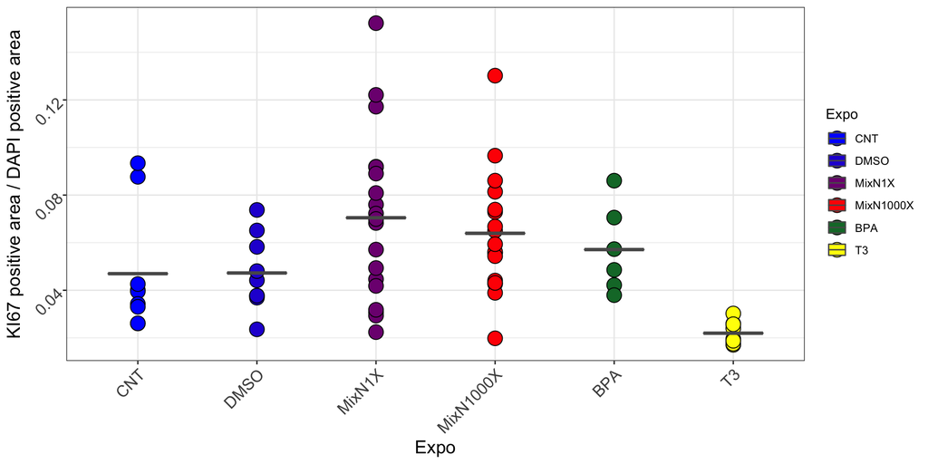

```r
KI$Expo <- factor(KI$Expo, levels=c("CNT","DMSO","MixN1X","MixN1000X","BPA","T3" ))

SampleColors <- c("CNT"="#0000FF", "DMSO"="#2900D5", "MixN1X"="#7E0080", "MixN1000X"="#FF0000", "BPA"="#117733", "T3"="yellow")
plot <- ggplot(data=KI, aes(Expo,ratio, fill=Expo))+
    geom_jitter(position=position_dodge(0.6), size=5, pch=21) +
    stat_summary(fun.y=mean, fun.ymin=mean, fun.ymax=mean,
                 geom="crossbar", width=0.5, col='gray35', position=position_dodge(0.6)) +
    scale_fill_manual(values=SampleColors) +
    theme_bw() + xlab('') +
    theme(plot.title = element_text(face='bold', colour='darkred', size=18, hjust=0.5),
          axis.title=element_text(size=14), axis.text=element_text(size=12.5, angle=45, hjust=1)) +
  ylab("KI67 positive area / DAPI positive area")+
  xlab("Expo")
plot
```

An alternative visualization for nested data:

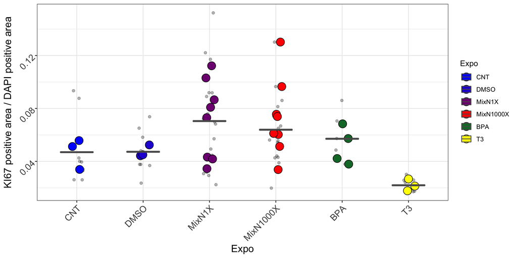

```r
ag <- aggregate(KI[,"ratio",drop=FALSE], by=KI[,c("Expo","organoid")], FUN=mean)
plot <- ggplot(data=KI, aes(Expo,ratio, fill=Expo))+
    geom_jitter(width = 0.1, height = 0, alpha=0.3) +
    geom_jitter(data=ag, width = 0.1, height = 0, size=5, pch=21) +
    stat_summary(fun.y=mean, fun.ymin=mean, fun.ymax=mean,
                 geom="crossbar", width=0.5, col='gray35', position=position_dodge(0.6)) +
    scale_fill_manual(values=SampleColors) +
    theme_bw() + xlab('') +
    theme(plot.title = element_text(face='bold', colour='darkred', size=18, hjust=0.5),
          axis.title=element_text(size=14), axis.text=element_text(size=12.5, angle=45, hjust=1)) +
  ylab("KI67 positive area / DAPI positive area")+
  xlab("Expo")
plot
```

### import data DCX

```r
DCX <- read.table("Data/Stainings/DCX/CNT.txt",header = F, sep="\t")
DCX <- as.data.frame(strsplit(as.character(DCX$V1),":"))
a <-  as.data.frame(DCX[2,c(2:5)], row.names = as.character(DCX[1,1]))
colnames(a)=c("DAPI low thresh", "DCX low thresh","Area DCX","Area DAPI")
for (i in 2:(length(colnames(DCX))/6))
  {
     b <- as.data.frame(DCX[2,c(2:5)+ 6*i -6], row.names = as.character(DCX[1,i*6 -5]))
     colnames(b) <- colnames(a)
     a <- rbind(a,  b)
  }
CNT <- a
CNT$Expo <- "CNT"

DCX <- read.table("Data/Stainings/DCX/DMSO.txt",header = F, sep="\t")
DCX <- as.data.frame(strsplit(as.character(DCX$V1),":"))
a <-  as.data.frame(DCX[2,c(2:5)], row.names = as.character(DCX[1,1]))
colnames(a)=c("DAPI low thresh", "DCX low thresh","Area DCX","Area DAPI")
for (i in 2:(length(colnames(DCX))/6))
  {
     b <- as.data.frame(DCX[2,c(2:5)+ 6*i -6], row.names = as.character(DCX[1,i*6 -5]))
     colnames(b) <- colnames(a)
     a <- rbind(a,  b)
  }
DMSO <- a
DMSO$Expo <- "DMSO"


DCX <- read.table("Data/Stainings/DCX/T3.txt",header = F, sep="\t")
DCX <- as.data.frame(strsplit(as.character(DCX$V1),":"))
a <-  as.data.frame(DCX[2,c(2:5)], row.names = as.character(DCX[1,1]))
colnames(a)=c("DAPI low thresh", "DCX low thresh","Area DCX","Area DAPI")
for (i in 2:(length(colnames(DCX))/6))
  {
     b <- as.data.frame(DCX[2,c(2:5)+ 6*i -6], row.names = as.character(DCX[1,i*6 -5]))
     colnames(b) <- colnames(a)
     a <- rbind(a,  b)
  }
T3 <- a
T3$Expo <- "T3"

DCX <- read.table("Data/Stainings/DCX/BPA.txt",header = F, sep="\t")
DCX <- as.data.frame(strsplit(as.character(DCX$V1),":"))
a <-  as.data.frame(DCX[2,c(2:5)], row.names = as.character(DCX[1,1]))
colnames(a)=c("DAPI low thresh", "DCX low thresh","Area DCX","Area DAPI")
for (i in 2:(length(colnames(DCX))/6))
  {
     b <- as.data.frame(DCX[2,c(2:5)+ 6*i -6], row.names = as.character(DCX[1,i*6 -5]))
     colnames(b) <- colnames(a)
     a <- rbind(a,  b)
  }
BPA <- a
BPA$Expo <- "BPA"

DCX <- read.table("Data/Stainings/DCX/MixN1X.txt",header = F, sep="\t")
DCX <- as.data.frame(strsplit(as.character(DCX$V1),":"))
a <-  as.data.frame(DCX[2,c(2:5)], row.names = as.character(DCX[1,1]))
colnames(a)=c("DAPI low thresh", "DCX low thresh","Area DCX","Area DAPI")
for (i in 2:(length(colnames(DCX))/6))
  {
     b <- as.data.frame(DCX[2,c(2:5)+ 6*i -6], row.names = as.character(DCX[1,i*6 -5]))
     colnames(b) <- colnames(a)
     a <- rbind(a,  b)
  }
MixN1X <- a
MixN1X$Expo <- "MixN1X"

DCX <- read.table("Data/Stainings/DCX/MixN1000X.txt",header = F, sep="\t")
DCX <- as.data.frame(strsplit(as.character(DCX$V1),":"))
a <-  as.data.frame(DCX[2,c(2:5)], row.names = as.character(DCX[1,1]))
colnames(a)=c("DAPI low thresh", "DCX low thresh","Area DCX","Area DAPI")
for (i in 2:(length(colnames(DCX))/6))
  {
     b <- as.data.frame(DCX[2,c(2:5)+ 6*i -6], row.names = as.character(DCX[1,i*6 -5]))
     colnames(b) <- colnames(a)
     a <- rbind(a,  b)
  }
MixN1000X <- a
MixN1000X$Expo <- "MixN1000X"

DCX <- rbind(CNT,DMSO,T3,BPA,MixN1X,MixN1000X)
DCX$`DAPI low thresh`<- as.numeric(as.character(DCX$`DAPI low thresh`))
DCX$`DCX low thresh`<- as.numeric(as.character(DCX$`DCX low thresh`))
DCX$`Area DCX`<- as.numeric(as.character(DCX$`Area DCX`))
DCX$`Area DAPI`<- as.numeric(as.character(DCX$`Area DAPI`))
DCX$ratio <- DCX$`Area DCX`/DCX$`Area DAPI`
```

### Violin plot the ratio between DCXarea and DAPIarea

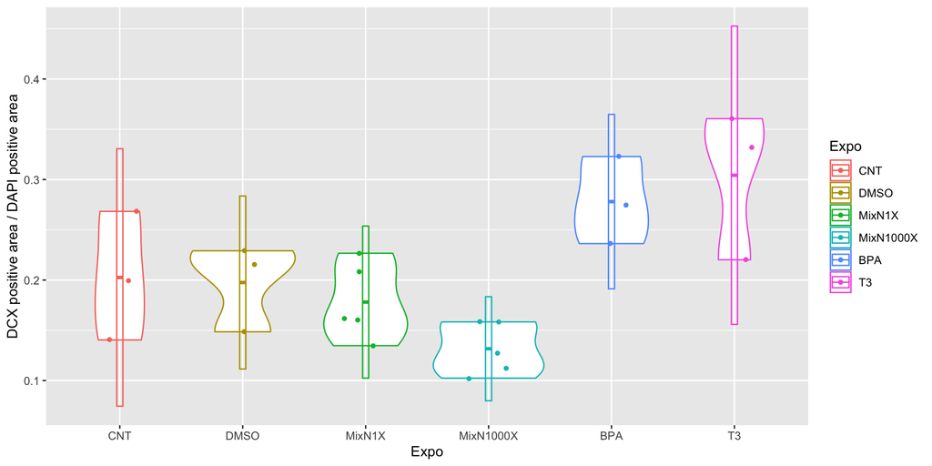

```r
#boxplot(KI67$ratio~KI67$Expo)
DCX$Expo <- factor(DCX$Expo, levels=c("CNT","DMSO","MixN1X","MixN1000X","BPA","T3" ))
DCX$SampleColors <- c(rep("#0000FF",3), rep("#2900D5",3), rep("yellow", 3), rep("#117733",3), rep("#7E0080",5), rep("#FF0000",5))
#KI$Expo <- factor(KI$Expo, levels=c("Y", "X", "Z"))
ggplot(DCX, aes(x=Expo, y=ratio, color=Expo)) +
geom_violin() +
stat_summary(fun.data="mean_sdl", geom="crossbar", width=0.05) +
geom_jitter(shape=16, position=position_jitter(0.2)) +
ylab("DCX positive area / DAPI positive area")
```

### plot the ratio between between DCXarea and DAPIarea quantified on entire organoids

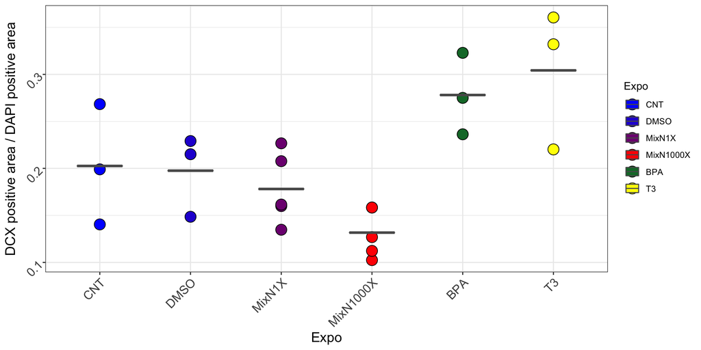

```r
DCX$Expo <- factor(DCX$Expo, levels=c("CNT","DMSO","MixN1X","MixN1000X","BPA","T3" ))

SampleColors <- c("CNT"="#0000FF", "DMSO"="#2900D5", "MixN1X"="#7E0080", "MixN1000X"="#FF0000", "BPA"="#117733", "T3"="yellow")
plot <- ggplot(data=DCX, aes(Expo,ratio, fill=Expo))+
    geom_jitter(position=position_dodge(0.6), size=5, pch=21) +
    stat_summary(fun.y=mean, fun.ymin=mean, fun.ymax=mean,
                 geom="crossbar", width=0.5, col='gray35', position=position_dodge(0.6)) +
    scale_fill_manual(values=SampleColors) +
    theme_bw() + xlab('') +
    theme(plot.title = element_text(face='bold', colour='darkred', size=18, hjust=0.5),
          axis.title=element_text(size=14), axis.text=element_text(size=12.5, angle=45, hjust=1)) +
  ylab("DCX positive area / DAPI positive area")+
  xlab("Expo")
plot
```

### Statistical tests

```r
mod <- lm(log(`Area DCX`)~offset(log(`Area DAPI`))+Expo, data=DCX)
coefficients(summary(mod))[-1,]
```

```
##                   Estimate Std. Error     t value   Pr(>|t|)
## ExpoDMSO      -0.008027809  0.1875312 -0.04280787 0.96638437
## ExpoMixN1X    -0.112295586  0.1677330 -0.66949022 0.51272896
## ExpoMixN1000X -0.412033503  0.1677330 -2.45648482 0.02583516
## ExpoBPA        0.343005088  0.1875312  1.82905645 0.08609116
## ExpoT3         0.419119968  0.1875312  2.23493501 0.04003302
```

```r
DCX$expo2 <- DCX$Expo
levels(DCX$expo2) <- c("CNT","CNT","MixN","MixN", "BPA", "T3")
mod <- lm(log(`Area DCX`)~offset(log(`Area DAPI`))+expo2, data=DCX)
coefficients(summary(mod))[-1,]
```

```
##             Estimate Std. Error   t value   Pr(>|t|)
## expo2MixN -0.2581506  0.1258296 -2.051588 0.05505077
## expo2BPA   0.3470190  0.1722993  2.014047 0.05919851
## expo2T3    0.4231339  0.1722993  2.455807 0.02444831
```

### Transcriptomic associated data

### Proliferation

```r
load("Data/AllSEcorrected.RData", verbose = T)
```

```
## Loading objects:
##   SEs
##   DEAs
```

```r
load("Data/DEGsOrganoidsChronic.RData",verbose = T)
```

```
## Loading objects:
##   org.chronic
##   org.chronicLong
```

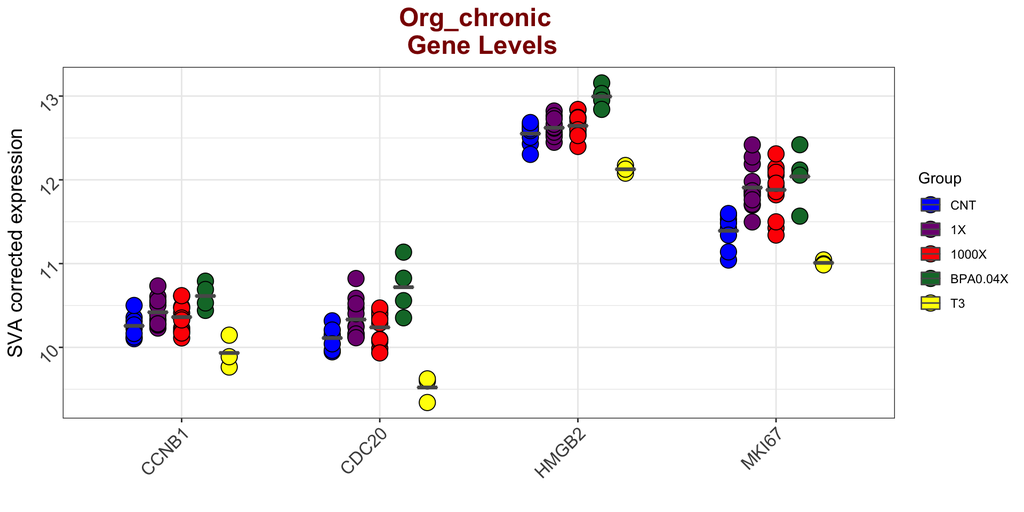

```r
Org_chronic <- SEs$chronic.org[,which(SEs$chronic.org$EXPO=="CNT"|SEs$chronic.org$EXPO=="1X" | SEs$chronic.org$EXPO=="1000X" | SEs$chronic.org$EXPO=="BPA0.04X" | SEs$chronic.org$EXPO=="T3")]
#ProlGenes <- c('MKI67','CCNB1', 'CCNB2', 'CDC20', 'CDC20B', 'CDCA8', 'HMGB2')
#geneStripPairEDCMix(SE = Org_chronic,GeneSet = ProlGenes,printExp = FALSE,SampleColors = "Default")
ProlGenes <- c('MKI67','CCNB1', 'CDC20', 'HMGB2')
geneStripPairEDCMix(SE = Org_chronic,GeneSet = ProlGenes,printExp = FALSE,SampleColors = "Default")
```

#### P values for MIX N

```r
PVals <- DEAs$chronic.org[ProlGenes,]
PVals <- PVals[complete.cases(PVals), ]
PVals
##       logFC.EXPO1X logFC.EXPO1000X   logCPM         F     PValue        FDR
## MKI67    0.5158631      0.47797089 7.179763 4.1450790 0.02432131 0.09845604
## CCNB1    0.1571566      0.09338588 5.662209 0.9141929 0.41029016 0.56941503
## CDC20    0.2228841      0.11457047 5.573279 1.0834085 0.34962845 0.51233616
## HMGB2    0.0578860      0.08059550 7.969252 0.5347055 0.59059752 0.71801280
```

- Genes with conventional PVal > 0.05: CCNB1, CDC20, HMGB2
- Genes with conventional PVal < 0.05: MKI67
- Genes with conventional FDR < 0.05:

#### P values for T3

```r
load("Data/DEAorgSingleCompunds.RData", verbose=TRUE)
## Loading objects:
##   res.orgT3
##   res.orgBPA
PVals <- res.orgT3[ProlGenes,]
PVals <- PVals[complete.cases(PVals), ]
PVals
##            logFC   logCPM         F       PValue         FDR
## MKI67 -0.4316251 7.179763  2.369536 0.1328066900 0.267152693
## CCNB1 -0.3840033 5.662209  4.473368 0.0416925114 0.116328310
## CDC20 -0.7155889 5.573279  8.399397 0.0064679535 0.029175767
## HMGB2 -0.4727221 7.969252 15.555194 0.0003714244 0.003406081
```

- Genes with conventional PVal > 0.05: MKI67
- Genes with conventional PVal < 0.05: CCNB1
- Genes with conventional FDR < 0.05: CDC20, HMGB2

#### P values for BPA

```r
load("Data/DEAorgSingleCompunds.RData", verbose=TRUE)
## Loading objects:
##   res.orgT3
##   res.orgBPA
PVals <- res.orgBPA[ProlGenes,]
PVals <- PVals[complete.cases(PVals), ]
PVals
##           logFC   logCPM         F       PValue          FDR
## MKI67 0.6809718 7.179763 11.679921 1.630579e-03 0.0150459679
## CCNB1 0.3895131 5.662209  9.144768 4.673363e-03 0.0304629216
## CDC20 0.6909414 5.573279 16.899461 2.293352e-04 0.0040934070
## HMGB2 0.4415802 7.969252 25.607486 1.369475e-05 0.0006104268
```

- Genes with conventional PVal > 0.05:
- Genes with conventional PVal < 0.05:
- Genes with conventional FDR < 0.05: MKI67, CCNB1, CDC20, HMGB2

### Neuronal Differentiation

```r
load("Data/AllSEcorrected.RData", verbose = T)
```

```
## Loading objects:
##   SEs
##   DEAs
```

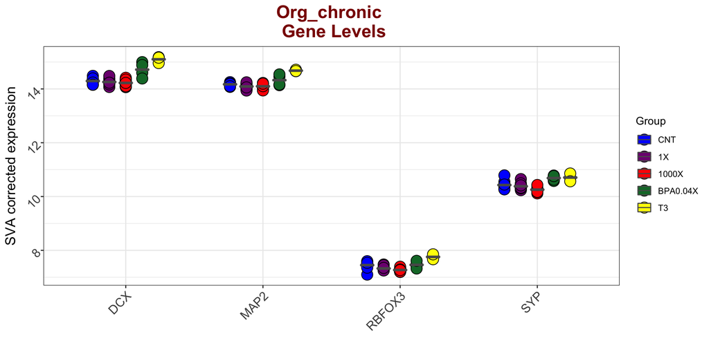

```r
#NeuronGenes <- c('DCX',"SATB2","NEUROG1","SYP","MAP2","RBFOX3","L1CAM")
#geneStripPairEDCMix(SE = Org_chronic,GeneSet = NeuronGenes,printExp = FALSE, SampleColors = "Default")
NeuronGenes <- c('DCX',"SYP","MAP2","RBFOX3")
geneStripPairEDCMix(SE = Org_chronic,GeneSet = NeuronGenes,printExp = FALSE, SampleColors = "Default")
```

#### P values for MIX N

```r
PVals <- DEAs$chronic.org[NeuronGenes,]
PVals <- PVals[complete.cases(PVals), ]
PVals
##        logFC.EXPO1X logFC.EXPO1000X   logCPM         F     PValue       FDR
## DCX     -0.04485794     -0.08371969 9.808547 0.4310941 0.65323502 0.7659654
## SYP     -0.07111726     -0.21076232 5.675611 3.6125359 0.03758126 0.1282101
## MAP2    -0.09206050     -0.08913764 9.567773 0.8878417 0.42069713 0.5782503
## RBFOX3  -0.30662511     -0.43254504 1.474974 3.7034481 0.03486353 0.1219995
```

- Genes with conventional PVal > 0.05: DCX, MAP2
- Genes with conventional PVal < 0.05: SYP, RBFOX3
- Genes with conventional FDR < 0.05:

#### P values for T3

```r
load("Data/DEAorgSingleCompunds.RData", verbose=TRUE)
## Loading objects:
##   res.orgT3
##   res.orgBPA
PVals <- res.orgT3[NeuronGenes,]
PVals <- PVals[complete.cases(PVals), ]
PVals
##            logFC   logCPM         F       PValue          FDR
## DCX    0.7751497 9.808547 28.404687 6.079119e-06 0.0001500374
## SYP    0.2560135 5.675611  3.282760 7.868525e-02 0.1843611264
## MAP2   0.4753571 9.567773 18.931729 1.136035e-04 0.0013758926
## RBFOX3 0.6095827 1.474974  6.192068 1.779189e-02 0.0618094061
```

- Genes with conventional PVal > 0.05: SYP
- Genes with conventional PVal < 0.05: RBFOX3
- Genes with conventional FDR < 0.05: DCX, MAP2

#### P values for BPA

```r
load("Data/DEAorgSingleCompunds.RData", verbose=TRUE)
## Loading objects:
##   res.orgT3
##   res.orgBPA
PVals <- res.orgBPA[NeuronGenes,]
PVals <- PVals[complete.cases(PVals), ]
PVals
##              logFC   logCPM            F       PValue         FDR
## DCX     0.42930443 9.808547 16.055671524 0.0003098608 0.005050019
## SYP     0.25608904 5.675611  6.013271839 0.0193830760 0.080749618
## MAP2    0.15271212 9.567773  3.501767167 0.0697659399 0.194436446
## RBFOX3 -0.01012511 1.474974  0.003345398 0.9542087935 0.978916341
```

- Genes with conventional PVal > 0.05: MAP2, RBFOX3
- Genes with conventional PVal < 0.05: SYP
- Genes with conventional FDR < 0.05: DCX

### Index

MixN_Acute

MixN_ChronicFetal

FunctionalFetalChronicMixN

MixN_ChronicOrganoids

FunctionalOrganoidChronicMixN

MixNVsSingleCompounds

MasterRegulatorAnalysis

HormonalPathways

Immunofluorescence

MixN_clustering

FunctionalClustering

DoseResponseInVivo

### Authors

Nicolò Caporale: nicolo.caporale@ieo.it, nicolo.caporale@unimi.it

Cristina Cheroni: cristina.cheroni@ieo.it

Pierre-Luc Germain: pierre-luc.germain@ieo.it

Giuseppe Testa: giuseppe.testa@ieo.it

Lab: http://www.testalab.eu/

‘Date: December 01, 2021’